# TP2_NAOUMI_KILANI

```python
%load_ext autotime
```

```
The autotime extension is already loaded. To reload it, use:
  %reload_ext autotime
time: 1.49 ms
```

## TP2 : Classification using Linear & Quadratic Discriminant Analysis

First think of configuring your notebook :

```python
import csv
# import os
from pylab import *
import numpy as np
from numpy import linalg as la
import matplotlib.pyplot as plt
import pandas as pd
from sklearn.neighbors import KNeighborsClassifier
from sklearn.model_selection import cross_val_score
import random
```

```
time: 993 µs
```

## Reading synthetic data

Load the training and test data sets |synth_train.txt| and |synth_test.txt| already used for Knn. Targets belong to {1,2} and entries belong to R^2. We have 100 training data samples and 200 test samples.

- the 1st column contains the label of the class the sample,
- columns 2 & 3 contain the coordinates of each sample in 2D.

```python
train = np.loadtxt('synth_train.txt')

test = np.loadtxt('synth_test.txt')
```

```
time: 1.7 s
```

```python
print("The training set has : %d rows of data" % train.shape[0])
print('--'*50)
print("The test set has : %d rows of data " % test.shape[0])
```

```
The training set has : 100 rows of data
----------------------------------------------------------------------------------------------------
The test set has : 200 rows of data
time: 988 µs
```

For further comparisons, we are going to keep the same ratio of data ($\frac{1}{3}$ training || $\frac{2}{3}$ testing )

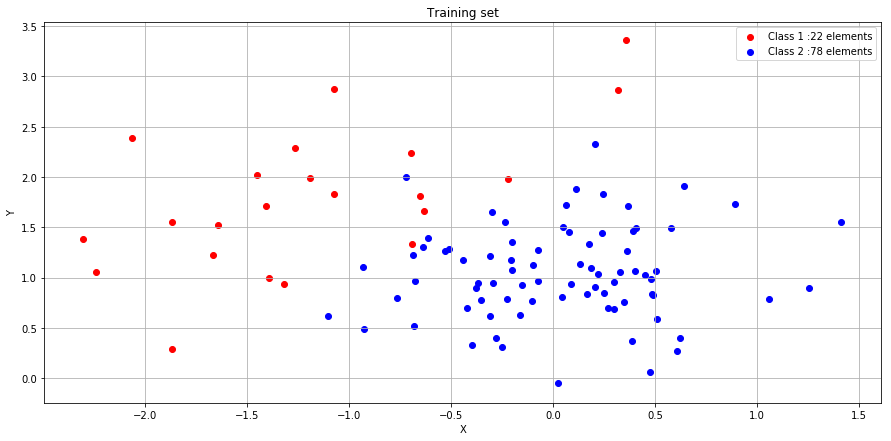

```
time: 1 s
```

```python
plt.figure(figsize=(15,7))
plt.grid()
plt.title("Training set")
plt.xlabel("X")
plt.ylabel("Y")
plt.scatter(train[train[:,0]==1][:,1],train[train[:,0]==1][:,2], color="r",label="Class 1 :"+str(len(train[train[:,0]==1]))+ " elements")
plt.scatter(train[train[:,0]==2][:,1],train[train[:,0]==2][:,2], color="b",label="Class 2 :"+str(len(train[train[:,0]==2]))+ " elements")
plt.legend();
```

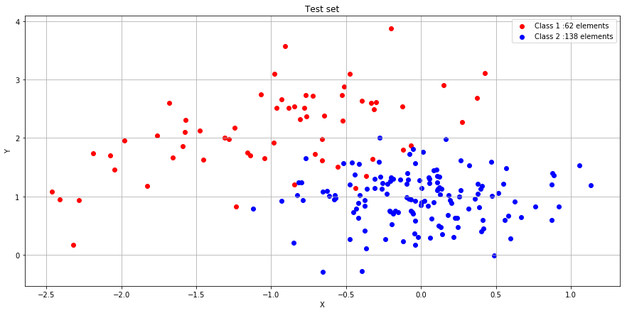

```
time: 165 ms
```

```python
plt.figure(figsize=(15,7))
plt.grid()
plt.title("Test set")
plt.xlabel("X")
plt.ylabel("Y")
plt.scatter(test[test[:,0]==1][:,1],test[test[:,0]==1][:,2], color="r",label="Class 1 :"+str(len(test[test[:,0]==1]))+ " elements")
plt.scatter(test[test[:,0]==2][:,1],test[test[:,0]==2][:,2], color="b",label="Class 2 :"+str(len(test[test[:,0]==2]))+ " elements")
plt.legend();
```

A quick overview on the data make us observe that there is far less Class 1 elements ( 2 thirds less than Class 2 in the training set and half less than Class 2 in the test set)

## Recall about the main steps of discriminant analysis:

- estimation of weights `pi_1` and `pi_2` for each class,
- estimation of empirical means `mu_1` and `mu_2` for each class,
- estimation of empirical covariance matrices `sigma_1` and `sigma_2`,
- computation of the common averaged covariance `sigma` (average of intra-class covariances),
- computation of log-probabilities of belonging to each class,
- decision of classification,
- display results.

```python
def weight(data,clas,dim_clas): # input: - training data
                                #        -the class for which we want the weight
                                #        -in which column of the training data we can find the label (class)
    return len(data[data[:,dim_clas]==clas])/len(data)
def means(data,clas):# input: - training data
                     #        -the class for which we want the mean
    return np.array([np.mean(data[data[:,0]==clas][:,1]),np.mean(data[data[:,0]==clas][:,2])])
def sigma(data,clas):# input: - training data
                     #        -the class for which we want the cov matrix
    return np.cov(data[data[:,0]==clas][:,1],data[data[:,0]==clas][:,2])
def com_avg_cov(data,T_class):# input: - training data
                              #        -a list of the classes we got
                              # returns: - avg weighted covariance matrix of all the classes
    clas1=T_class[0]
    clas2=T_class[1]
    sigma_1=sigma(data,clas1)
    sigma_2=sigma(data,clas2)
    res=np.zeros((len(T_class),len(T_class)))
    for i in T_class:
        res+=weight(data,i,0)*sigma(data,i)
    return res
def log_proba_LDA(data,T_class,x): # Returns a list of probabilities (log Probabilities)
                                   # where the P (log P) of belonging to a class K is at the Kth position.
                                   # All this using the avg cov matrix of all the classes
    X=np.array(x)
    W=np.zeros(len(T_class))
    MU=[]
    SIGMA=com_avg_cov(data,T_class)
    frac=[]
    for i in range(len(T_class)):
        W[i]=weight(data,T_class[i],0)
        MU.append(means(train,T_class[i]))
        frac.append(W[i]*np.exp(-.5*(X-MU[i]).dot(np.linalg.inv(SIGMA).dot((X-MU[i]).T))))
    P=frac/np.sum(frac)
    return P,np.log(P)
def log_proba_QDA(data,T_class,x):  # Returns a list of probabilities (log Probabilities)
                                   # where the P (log P) of belonging to a class K is at the Kth position.
                                   # All this using the cov matrix of each class
    X=np.array(x)
    W=np.zeros(len(T_class))
    MU=[]
    SIGMA=[]
    frac=[]
    for i in range(len(T_class)):
        W[i]=weight(data,T_class[i],0)
        MU.append(means(train,T_class[i]))
        SIGMA.append(sigma(data,T_class[i]))
        frac.append(W[i]*np.exp(-.5*(X-MU[i]).dot(np.linalg.inv(SIGMA[i]).dot((X-MU[i]).T))))
    P=frac/np.sum(frac)
    return P,np.log(P)
def decision(data,T_class,x,mode):# input: - training data
                                  #        - a list of the classes we have in the training set
                                  #        - the 2D dot to classify
                                  #        - using LDA or QDA
    if mode=='LDA':
        return T_class[log_proba_LDA(data,T_class,x)[0].argmax()]
    elif mode=='QDA':
        return T_class[log_proba_QDA(data,T_class,x)[0].argmax()]
```

```
time: 7.44 ms
```

Let us apply this to our training dataset

```python
pi_1=weight(train,1,0)
pi_2=weight(train,2,0)
mu_1=means(train,1)
mu_2=means(train,2)
sigma_1=sigma(train,1)
sigma_2=sigma(train,2)
print("The proportion of Class 1 in the training set is :"+str((pi_1*100))+" %")
print("The proportion of Class 2 in the training set is :"+str((pi_2*100))+" %")
print('--'*50)
print("The mean of Class 1 in the training set is : ("+str((mu_1[0]))+', '+str((mu_1[1]))+" )")
print("The mean of Class 2 in the training set is : ("+str((mu_2[0]))+', '+str((mu_2[1]))+" )")
print('--'*50)
print("The cov matrix of Class 1 in the training set is : ["+ str(sigma_1[0]))
print("                                                    "+ str(sigma_1[1])+"]")
print("The cov matrix of Class 2 in the training set is : ["+ str(sigma_2[0]))
print("                                                    "+ str(sigma_2[1])+"]")
```

```
The proportion of Class 1 in the training set is :22.0 %
The proportion of Class 2 in the training set is :78.0 %
----------------------------------------------------------------------------------------------------
The mean of Class 1 in the training set is : (-1.1835069308058637, 1.786554365666049 )
The mean of Class 2 in the training set is : (0.02868972853445678, 1.0442454763868372 )
----------------------------------------------------------------------------------------------------
The cov matrix of Class 1 in the training set is : [[0.54124863 0.32258376]
                                                    [0.32258376 0.51088153]]
The cov matrix of Class 2 in the training set is : [[0.24599115 0.01961141]
                                                    [0.01961141 0.21154879]]
time: 140 ms
```

```python
Nx1=70 # number of samples for display
Nx2=70
x1=np.linspace(-2.5,1.5,Nx1)  # sampling of the x1 axis
x2=np.linspace(-0.5,4,Nx2)  # sampling of the x2 axis
X1,X2=np.meshgrid(x1,x2)
Z1=sigma_1[0][0]*(X1-mu_1[0])**2+sigma_1[0][1]*(X2-mu_1[1])**2
Z2=sigma_2[0][0]*(X1-mu_2[0])**2+sigma_2[0][1]*(X2-mu_2[1])**2
```

```
time: 2.98 ms
```

Using these quantities, let us plot a contour line of the variance ($=0.2$ for class 1 and $0.02$ for class 2)

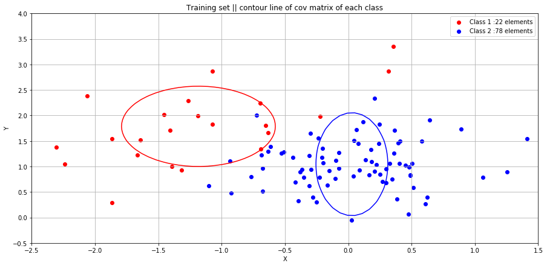

```
time: 174 ms
```

```python
plt.figure(figsize=(15,7))
plt.grid()
plt.title("Training set || contour line of cov matrix of each class")
plt.xlabel("X")
plt.ylabel("Y")
plt.scatter(train[train[:,0]==1][:,1],train[train[:,0]==1][:,2], color="r",label="Class 1 :"+str(len(train[train[:,0]==1]))+ " elements")
plt.scatter(train[train[:,0]==2][:,1],train[train[:,0]==2][:,2], color="b",label="Class 2 :"+str(len(train[train[:,0]==2]))+ " elements")
plt.contour(X1, X2, Z1, 0.2,colors="r")
plt.contour(X1, X2, Z2, 0.02,colors="b")
plt.legend();
```

```python
avg_sigma=com_avg_cov(train,[1,2])
print("The avg weighted cov matrix of the two classed in the training set is : ["+ str(avg_sigma[0]))
print("                                                                         "+ str(avg_sigma[1])+"]")
Z3=avg_sigma[0][0]*(X1-mu_1[0])**2+avg_sigma[0][1]*(X2-mu_1[1])**2
Z4=avg_sigma[0][0]*(X1-mu_2[0])**2+avg_sigma[0][1]*(X2-mu_2[1])**2
```

```
The avg weighted cov matrix of the two classed in the training set is : [[0.3109478  0.08626533]
                                                                         [0.08626533 0.277402  ]]
time: 3.47 ms
```

Using this quantity, we plot a contour line of the variance ($=0.07$ for each of the classes)

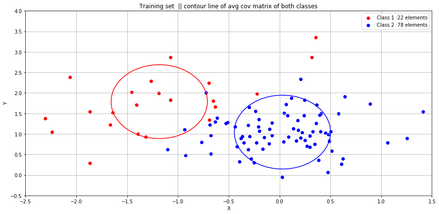

```
time: 163 ms
```

```python
plt.figure(figsize=(15,7))
plt.grid()
plt.title("Training set  || contour line of avg cov matrix of both classes")
plt.xlabel("X")
plt.ylabel("Y")
plt.scatter(train[train[:,0]==1][:,1],train[train[:,0]==1][:,2], color="r",label="Class 1 :"+str(len(train[train[:,0]==1]))+ " elements")
plt.scatter(train[train[:,0]==2][:,1],train[train[:,0]==2][:,2], color="b",label="Class 2 :"+str(len(train[train[:,0]==2]))+ " elements")
plt.contour(X1, X2, Z3, 0.07,colors="r")
plt.contour(X1, X2, Z4, 0.07,colors="b")
plt.legend();
```

Using the log_proba_function, let's try to determine where the dot $(0,0)$ belongs.

By looking at the plot, we may think of it as belonging to the Class 2 (Blue class)

```python
log_proba_LDA(train,[1,2],[0,0])
```

```
(array([3.63845059e-05, 9.99963615e-01]),
 array([-1.02213675e+01, -3.63851678e-05]))
```

```
time: 4.96 ms
```

Indeed the biggest Probability (thus the smallest -log(P) ) is the one in the 2nd position ==> Class 2

we verify that the probabilities sum up to 1 ( we did not calculate the probabilities using $1- the other$)...

```python
log_proba_LDA(train,[1,2],[0,0])[0].sum()
```

```
1.0
```

```
time: 3.97 ms
```

Same thing using QDA

```python
log_proba_QDA(train,[1,2],[0,0])
```

```
(array([6.02224016e-05, 9.99939778e-01]),
 array([-9.71746616e+00, -6.02242150e-05]))
```

```
time: 3.47 ms
```

we verify also

```python
log_proba_QDA(train,[1,2],[0,0])[0].sum()
```

```
1.0
```

```
time: 3.97 ms
```

We wrap all this together in this single function that will return the predicted label

```python
decision(train,[1,2],[-2,2],'LDA')
```

```
1
```

```
time: 3.47 ms
```

```python
decision(train,[1,2],[0,0],'QDA')
```

```
2
```

```
time: 3.93 ms
```

## TO DO : linear & quadratic discriminant analysis (LDA & QDA)

1. Implement a classifier using LDA of the data set.
2. Then implement QDA classification.
3. In each case (LDA & QDA) show the decision boundary and compute the error rate respectively for the training set and the test set.
4. Compare and comment on your results with LDA and QDA.
5. You may also compare your results to K nearest neighbours.

*Indication 1 : matrices `sigma` are of size 2x2. More generally, be careful of the sizes of vectors and matrices you manipulate.*

*Indication 2 : to display the regions of decision, you may use:*

```python
Nx1=70 # number of samples for display
Nx2=70
x1=np.linspace(-2.5,1.5,Nx1)  # sampling of the x1 axis
x2=np.linspace(-0.5,4,Nx2)  # sampling of the x2 axis
```

```
time: 977 µs
```

**We first classify each dot of the defined grid**

```python
GRID=[]
for x in x1:
    for y in x2:
        dot=[x,y]
        cl=decision(train,[1,2],dot,'LDA')
        GRID.append([cl,x,y])
GRID=np.array(GRID)
```

```
time: 1.86 s
```

```python
GRID
```

```
array([[ 1.        , -2.5       , -0.5       ],
       [ 1.        , -2.5       , -0.43478261],
       [ 1.        , -2.5       , -0.36956522],
       ...,
       [ 2.        ,  1.5       ,  3.86956522],
       [ 2.        ,  1.5       ,  3.93478261],
       [ 2.        ,  1.5       ,  4.        ]])
```

```
time: 3.97 ms
```

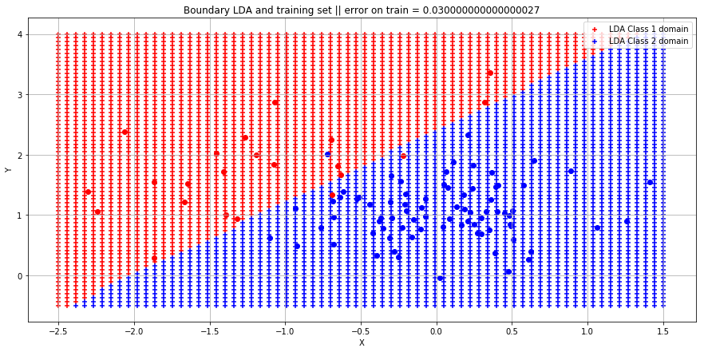

```
time: 347 ms
```

```python
plt.figure(figsize=(15,7))
plt.grid()
plt.xlabel("X")
plt.ylabel("Y")
plt.scatter(GRID[GRID[:,0]==1][:,1],GRID[GRID[:,0]==1][:,2], color="r",label="LDA Class 1 domain",marker="+")
plt.scatter(GRID[GRID[:,0]==2][:,1],GRID[GRID[:,0]==2][:,2], color="b",label="LDA Class 2 domain",marker="+")
plt.scatter(train[train[:,0]==1][:,1],train[train[:,0]==1][:,2], color="r")
plt.scatter(train[train[:,0]==2][:,1],train[train[:,0]==2][:,2], color="b")
C=[]
for dot in train[:,1:]:
    C.append(decision(train,[1,2],dot,"LDA"))
T=(np.array(C)==train[:,0])
plt.title("Boundary LDA and training set || error on train = "+str(1-(np.count_nonzero(T)/len(train))))
plt.legend();
```

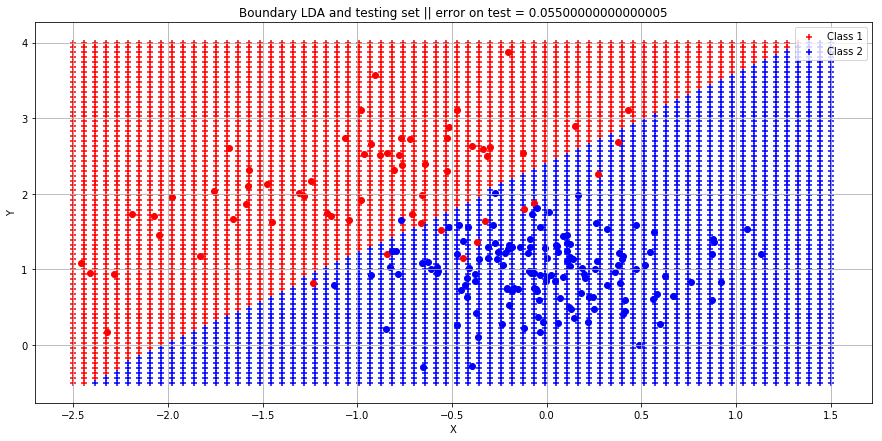

```
time: 382 ms
```

```python
plt.figure(figsize=(15,7))
plt.grid()
plt.title("Boundary LDA and test set")
plt.xlabel("X")
plt.ylabel("Y")
plt.scatter(GRID[GRID[:,0]==1][:,1],GRID[GRID[:,0]==1][:,2], color="r",label="Class 1",marker="+")
plt.scatter(GRID[GRID[:,0]==2][:,1],GRID[GRID[:,0]==2][:,2], color="b",label="Class 2",marker="+")
plt.scatter(test[test[:,0]==1][:,1],test[test[:,0]==1][:,2], color="r")
plt.scatter(test[test[:,0]==2][:,1],test[test[:,0]==2][:,2], color="b")
C=[]
for dot in test[:,1:]:
    C.append(decision(train,[1,2],dot,"LDA"))
T=(np.array(C)==test[:,0])
errLDA=(1-(np.count_nonzero(T)/len(test)))
plt.title("Boundary LDA and testing set || error on test = "+str(errLDA))
plt.legend();
```

```python
print("The Linear boundary separates the test data with a missclassification error of "+ str(errLDA)+" %")
print("--"*50)
```

[output not shown]

**Let see now how QDA performs**

```python
GRID=[]
for x in x1:
    for y in x2:
        dot=[x,y]
        cl=decision(train,[1,2],dot,'QDA')
        GRID.append([cl,x,y])
GRID=np.array(GRID)
```

```
time: 1.21 s
```

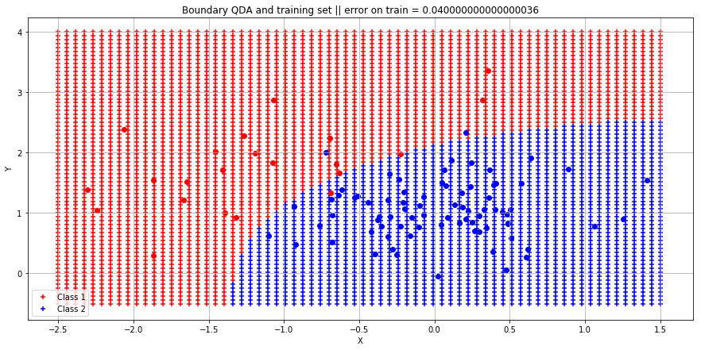

```
time: 1.81 s
```

```python
plt.figure(figsize=(15,7))
plt.grid()
plt.xlabel("X")
plt.ylabel("Y")
plt.scatter(GRID[GRID[:,0]==1][:,1],GRID[GRID[:,0]==1][:,2], color="r",label="Class 1",marker="+")
plt.scatter(GRID[GRID[:,0]==2][:,1],GRID[GRID[:,0]==2][:,2], color="b",label="Class 2",marker="+")
plt.scatter(train[train[:,0]==1][:,1],train[train[:,0]==1][:,2], color="r")
plt.scatter(train[train[:,0]==2][:,1],train[train[:,0]==2][:,2], color="b")
C=[]
for dot in train[:,1:]:
    C.append(decision(train,[1,2],dot,"QDA"))
T=1*(np.array(C)==train[:,0])
plt.title("Boundary QDA and training set || error on train = "+str(1-(T.sum()/len(train))))
plt.legend();
```

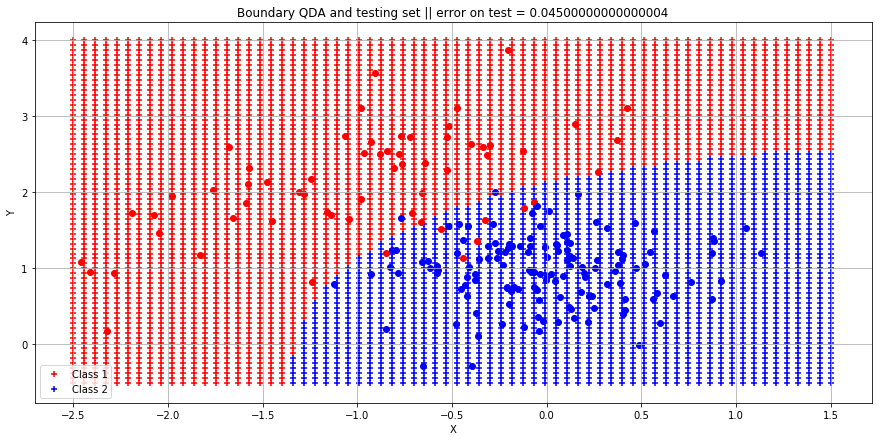

```
time: 345 ms
```

```python
plt.figure(figsize=(15,7))
plt.grid()
plt.xlabel("X")
plt.ylabel("Y")
plt.scatter(GRID[GRID[:,0]==1][:,1],GRID[GRID[:,0]==1][:,2], color="r",label="Class 1",marker="+")
plt.scatter(GRID[GRID[:,0]==2][:,1],GRID[GRID[:,0]==2][:,2], color="b",label="Class 2",marker="+")
plt.scatter(test[test[:,0]==1][:,1],test[test[:,0]==1][:,2], color="r")
plt.scatter(test[test[:,0]==2][:,1],test[test[:,0]==2][:,2], color="b")
C=[]
for dot in test[:,1:]:
    C.append(decision(train,[1,2],dot,"QDA"))
T=(np.array(C)==test[:,0])
errQDA=(1-np.count_nonzero(T)/len(test))
plt.title("Boundary QDA and testing set || error on test = "+str(errQDA))
plt.legend();
```

```python
print("The hyperbolic boundary separates the test data with a missclassification error of "+ str(errQDA)+" %")
print("--"*50)
```

[output not shown]

**Before drawing any conclusions, let's first see how the KNN performs on this data**

**What will be done here is :**

- using 10-Cross validation to choose the optimal value of K
- classifying the test data to assess the testing error

*(since we already computed manually KNN in the Introduction to Python course, and we performed cross validation in the TP1, we are not going to bother ourself by recomputing them here, this is why we use the built-in scikit learn corresponding libraries that are much faster)*

```python
cv_scores = []
neighbors=range(1,31) # we try values of neirest neighbors ranging from 1 to 30
for k in neighbors:
    knn = KNeighborsClassifier(n_neighbors=k)
    scores = cross_val_score(knn, train[:,1:], train[:,0], cv=10, scoring='accuracy')
    cv_scores.append(scores.mean())
```

```
time: 1.91 s
```

```
The optimal number of neighbors is 4
```

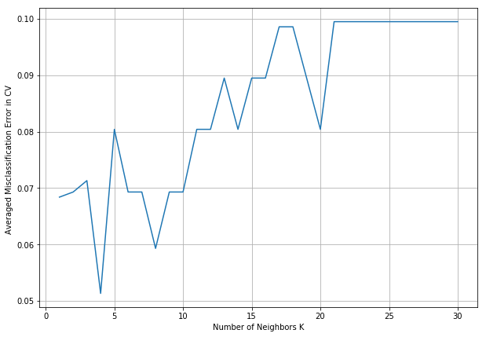

```
time: 117 ms
```

```python
MSE = [1 - x for x in cv_scores]

# determining best k
optimal_k = neighbors[MSE.index(min(MSE))] # The value of K we retain is the value which had the lowest cross validation MSE
print("The optimal number of neighbors is %d" % optimal_k)

# plot misclassification error vs k
plt.figure(figsize=(10,7))
plt.grid()
plt.plot(neighbors, MSE)
plt.xlabel('Number of Neighbors K')
plt.ylabel('Averaged Misclassification Error in CV ');
```

We fit the $K_{optimal}$ nearest neighbors algorithm on the training data

```python
neigh = KNeighborsClassifier(n_neighbors=optimal_k)
neigh.fit(train[:,1:], train[:,0])
class_pred=neigh.predict(train[:,1:])
T=train[:,0]-class_pred
T1=T[T!=0]
errtrain=len(T1)/len(test)
```

```
time: 2.97 ms
```

We predict the classes of the dots in the testing data and compute the missclassification error

```python
class_pred=neigh.predict(test[:,1:])
T=test[:,0]-class_pred
T1=T[T!=0]
errtest=len(T1)/len(test)
```

```
time: 1.97 ms
```

```python
GRID=[]
for x in x1:
    for y in x2:
        dot=[x,y]
        cl=neigh.predict([dot])
        GRID.append([cl,x,y])
GRID=np.array(GRID)
```

```
time: 1.11 s
```

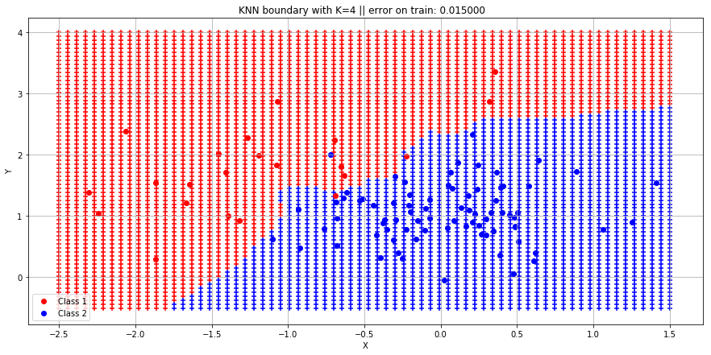

```
time: 323 ms
```

```python
plt.figure(figsize=(15,7))
plt.grid()
plt.xlabel("X")
plt.ylabel("Y")
plt.title("KNN boundary with K=%d || error on train: %f  " %(optimal_k,errtrain) )
plt.scatter(GRID[GRID[:,0]==1][:,1],GRID[GRID[:,0]==1][:,2], color="r",marker="+")
plt.scatter(GRID[GRID[:,0]==2][:,1],GRID[GRID[:,0]==2][:,2], color="b",marker="+")
plt.scatter(train[train[:,0]==1][:,1],train[train[:,0]==1][:,2], color="r",label="Class 1")
plt.scatter(train[train[:,0]==2][:,1],train[train[:,0]==2][:,2], color="b",label="Class 2")
plt.legend();
```

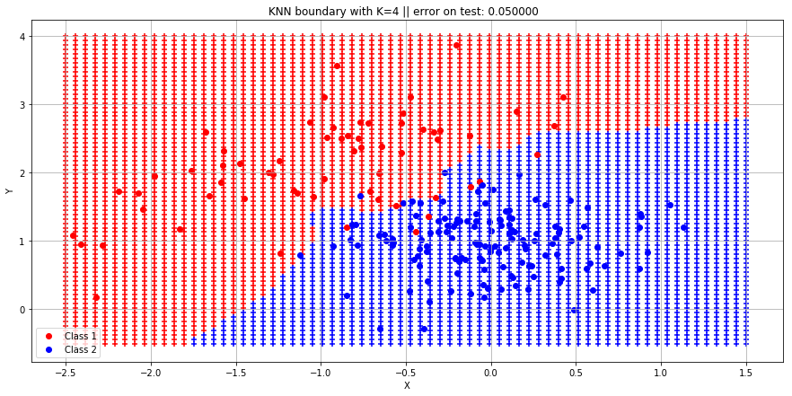

```
time: 295 ms
```

```python
plt.figure(figsize=(15,7))
plt.grid()
plt.xlabel("X")
plt.ylabel("Y")
plt.title("KNN boundary with K=%d || error on test: %f  " %(optimal_k,errtest) )
plt.scatter(GRID[GRID[:,0]==1][:,1],GRID[GRID[:,0]==1][:,2], color="r",marker="+")
plt.scatter(GRID[GRID[:,0]==2][:,1],GRID[GRID[:,0]==2][:,2], color="b",marker="+")
plt.scatter(test[test[:,0]==1][:,1],test[test[:,0]==1][:,2], color="r",label="Class 1")
plt.scatter(test[test[:,0]==2][:,1],test[test[:,0]==2][:,2], color="b",label="Class 2")
plt.legend();
```

```python
print("The generalisation error of LDA binary classifier = %f" % errLDA)
print('--'*50)
print("The generalisation error of QDA binary classifier = %f" % errQDA)
print('--'*50)
print("The generalisation error of %d-NN binary classifier = %f" %(optimal_k ,errtest))
print('--'*50)
```

```
The generalisation error of LDA binary classifier = 0.055000
----------------------------------------------------------------------------------------------------
The generalisation error of QDA binary classifier = 0.045000
----------------------------------------------------------------------------------------------------
The generalisation error of 4-NN binary classifier = 0.050000
----------------------------------------------------------------------------------------------------
time: 1.49 ms
```

**Conclusion**:

- The QDA seems to perform well followed by the KNN algorithm (K determined by 10-cross validation)
- the LDA is the less performant

**But what happens if we had another training set ? one can easily imagine that the KNN classifier will be largely impacted, but what for the two others for which the weights, means, and covariances of each of the classes will change?**

**To answer this question and build more robust conclusions, we will bootstrap the training data (resample with replacement) a certain number of times**

## Bootstraping and comparing the performance asymptotically:

```python
def resample_with_replacement(train):
    bs_train=[]
    for i in range(len(train)):
        bs_train.append(random.choice(train))
    return np.array(bs_train)
```

```
time: 520 µs
```

For time issues, we will boostrap the training data $100$ times

we will test on the same test set.

```python
errQDA=[]
errLDA=[]
errKNN=[]
N_experiences=100
for i in range(N_experiences):
    bs=resample_with_replacement(train)
    CLDA=[]
    CQDA=[]
    for dot in test[:,1:]:
        CLDA.append(decision(bs,[1,2],dot,"LDA"))
        CQDA.append(decision(bs,[1,2],dot,"QDA"))
    TLDA=1*(np.array(CLDA)==test[:,0])
    TQDA=1*(np.array(CQDA)==test[:,0])
    errLDA.append(1-(np.count_nonzero(TLDA)/len(test)))
    errQDA.append(1-(np.count_nonzero(TQDA)/len(test)))
    cv_scores = []
    neighbors=range(1,31)
    for k in neighbors:
        knn = KNeighborsClassifier(n_neighbors=k)
        scores = cross_val_score(knn, bs[:,1:], bs[:,0], cv=10, scoring='accuracy')
        cv_scores.append(scores.mean())
    MSE = [1 - x for x in cv_scores]

    # determining best k
    optimal_k = neighbors[MSE.index(min(MSE))]
    neigh = KNeighborsClassifier(n_neighbors=optimal_k)
    neigh.fit(bs[:,1:], bs[:,0])
    class_pred=neigh.predict(test[:,1:])
    T=test[:,0]-class_pred
    T1=T[T!=0]
    errKNN.append(len(T1)/len(test))
```

```
time: 42.7 s
```

Let's plot the results in boxplot to see how much the missclassification error varies in each case

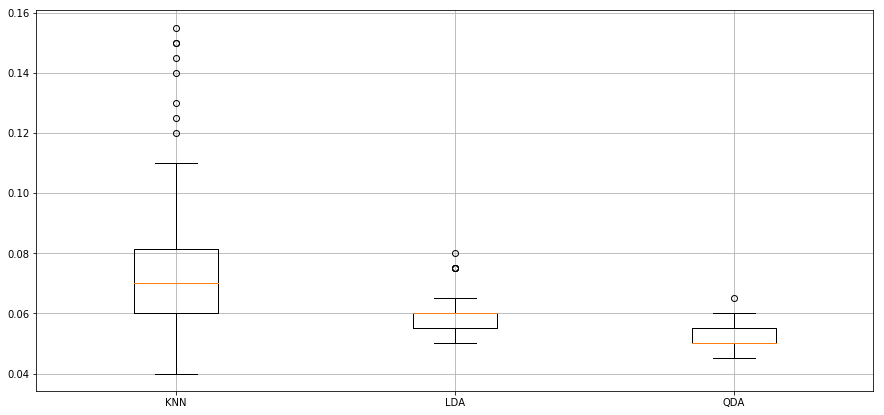

```
time: 120 ms
```

```python
plt.figure(figsize=(15,7))
plt.grid()
plt.boxplot([errKNN,errLDA,errQDA],labels=["KNN","LDA",'QDA']);
```

- The QDA classifier seems to be the most stable one (The missclassification error does not vary a lot and thus we can say that it is pretty much independant from the training set) ==> The good performance of QDA seems to be validated a bit more.
- As we said in the start, KNN classifier has a quiet big misclassification error variance. But that may be because it is very dependant of the chosen value of $K_{optimal}$: when cross-validating, it may happen that the training/cross validation set has some redundant records ( when bootstraping we resample with replacement), and thus the K resulting of the cros validation may not be the best one for the generalisation
- LDA is situated between the QDA and KNN but has a similar behavior as the QDA. (Stability)

**The next steps will be seeing how these algorithms perform when having multiple classes**

# Multiclass datasets:

**We wrap all the previous defined functions for LDA and QDA into one that outputs a dictionnary with all the results:**

- indices : Classes in the training set that we input
- pi: The weights of each population in the training set
- mu: The mean of each population in the training set
- Sigma: the avg cov matrix
- Alpha: the inverse of the avg cov matrix
- Probability Result for the Specified label: the probability that X belong to the class K given as an input
- Probabilities: an array of probabilities of belonging to a class i in the ith position
- Classification result: The class to which X belongs

```python
def Classifier(X,train,K, Algorithm):
    Training = train.copy()
    labels=np.unique(Training[:,0])
    assert K in labels
    N = Training.shape[0]
    D ={}
    D['indices']=list(labels)
    D['pi']= [np.count_nonzero(train[:,0]== i) / N for i in labels]
    D['mu']= [np.mean(Training[Training[:,0]== i][:,1:], axis =0) for i in labels]
    D['Y'] = X-np.array(D['mu'])
    Sigmas= [np.cov(Training[Training[:,0]== i][:,1], Training[Training[:,0]== i][:,2]) for i in labels]
    if (Algorithm == "LDA"):

        D['Sigma']= sum([D['pi'][k] *  Sigmas[k] for k in range(len(labels))],axis =0)
        D['Alpha'] =np.linalg.inv(D['Sigma'])
        IntermediateResults = [D['pi'][i] * np.exp(-0.5 * np.dot(D['Y'][i] ,np.dot(D['Alpha'],D['Y'][i]))) for i in range(len(labels))]
        D['Probabilities'] = IntermediateResults / np.sum(np.array(IntermediateResults))
    elif (Algorithm == "QDA"):
        D['sigmas']= Sigmas

        D['Alphas'] =[np.linalg.inv(sigma) for sigma in D['sigmas']]
        IntermediateResults= [D['pi'][i] * np.exp(-0.5 * np.dot(D['Y'][i] ,np.dot(D['Alphas'][i],D['Y'][i]))) for i in range(len(labels))]
        D['Probabilities'] = IntermediateResults / np.sum(np.array(IntermediateResults))

    D['Probability Result for the Specified label'] =D['Probabilities'][list(labels).index(K)]
    D['Classification Result']= int(labels[D['Probabilities'].argmax()])
    return D
```

```
time: 4 ms
```

## Iris dataset:

```python
from sklearn.datasets import load_iris

iris = load_iris()
```

```
time: 2.17 s
```

```python
print(iris.DESCR)
```

```
Iris Plants Database
====================

Notes
-----
Data Set Characteristics:
    :Number of Instances: 150 (50 in each of three classes)
    :Number of Attributes: 4 numeric, predictive attributes and the class
    :Attribute Information:
        - sepal length in cm
        - sepal width in cm
        - petal length in cm
        - petal width in cm
        - class:
                - Iris-Setosa
                - Iris-Versicolour
                - Iris-Virginica
    :Summary Statistics:

    ============== ==== ==== ======= ===== ====================
                    Min  Max   Mean    SD   Class Correlation
    ============== ==== ==== ======= ===== ====================
    sepal length:   4.3  7.9   5.84   0.83    0.7826
    sepal width:    2.0  4.4   3.05   0.43   -0.4194
    petal length:   1.0  6.9   3.76   1.76    0.9490  (high!)
    petal width:    0.1  2.5   1.20  0.76     0.9565  (high!)
    ============== ==== ==== ======= ===== ====================

    :Missing Attribute Values: None
    :Class Distribution: 33.3% for each of 3 classes.
    :Creator: R.A. Fisher
    :Donor: Michael Marshall (MARSHALL%PLU@io.arc.nasa.gov)
    :Date: July, 1988

This is a copy of UCI ML iris datasets.
http://archive.ics.uci.edu/ml/datasets/Iris

The famous Iris database, first used by Sir R.A Fisher

This is perhaps the best known database to be found in the
```

[output cut: 9 more lines]

```
     Annual Eugenics, 7, Part II, 179-188 (1936); also in "Contributions to
     Mathematical Statistics" (John Wiley, NY, 1950).
   - Duda,R.O., & Hart,P.E. (1973) Pattern Classification and Scene Analysis.
     (Q327.D83) John Wiley & Sons.  ISBN 0-471-22361-1.  See page 218.
   - Dasarathy, B.V. (1980) "Nosing Around the Neighborhood: A New System
     Structure and Classification Rule for Recognition in Partially Exposed
     Environments".  IEEE Transactions on Pattern Analysis and Machine
     Intelligence, Vol. PAMI-2, No. 1, 67-71.
   - Gates, G.W. (1972) "The Reduced Nearest Neighbor Rule".  IEEE Transactions
     on Information Theory, May 1972, 431-433.
   - See also: 1988 MLC Proceedings, 54-64.  Cheeseman et al"s AUTOCLASS II
     conceptual clustering system finds 3 classes in the data.
   - Many, many more ...

time: 495 µs
```

```python
iris.data.shape
```

```
(150, 4)
```

```
time: 2.48 ms
```

in order to apply our algorithms and **visualize** the results, we need to apply some dimensionality reduction algortihm to go from the 4 dimentional space to the 2D space.

What will be used is the Uniform Maniforld Approximation and Projection (UMAP) to perform this transformation. (https://www.youtube.com/watch?v=nq6iPZVUxZU , *PS: we did not understand this... but we will use it anyway*)

```python
import umap.umap_ as umap
```

```
time: 10.9 s
```

```python
embedding2 = umap.UMAP(n_neighbors=50,
                      learning_rate=0.5,
                      init="random",
                      min_dist=0.001)\
                .fit_transform(iris.data)
```

```
time: 5.29 s
```

```python
embedding2.shape
```

```
(150, 2)
```

```
time: 1.98 ms
```

```python
targets = np.array([d for d in iris.target])
# labels2 = np.array([targets2[d] for d in iris.target])
A12=targets[:,None]
A22 = np.concatenate((A12,embedding2),axis=1)
np.random.shuffle(A22)
Training_set , Testing_set = A22[:51,:] , A22[51:,:] # using the ratio 1/3 2/3 we talked of in the beginning
```

```
time: 34.7 ms
```

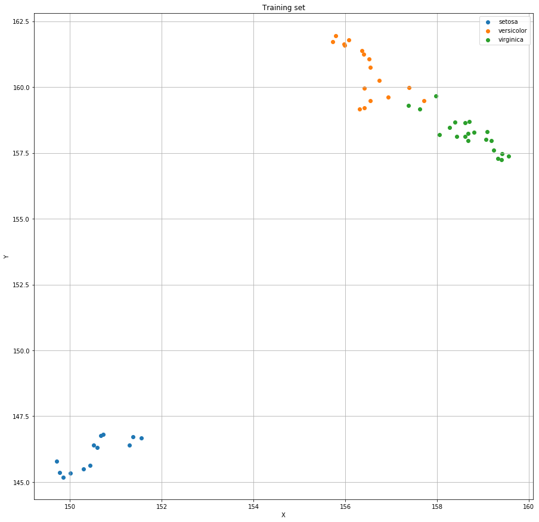

```
time: 193 ms
```

```python
plt.figure(figsize=(15,15))
plt.grid()
plt.title("Training set")
plt.xlabel("X")
plt.ylabel("Y")
for k in np.unique(targets) :
    plt.scatter(Training_set[Training_set[:,0]==k][:,1],Training_set[Training_set[:,0]==k][:,2], label=iris.target_names[k])
plt.legend();
```

**We build a grid and classify each dot of it using LDA classifyer**

```python
Nx1=70 # number of samples for display
Nx2=70
x1=np.linspace(145,168,Nx1)  # sampling of the x1 axis
x2=np.linspace(140,165,Nx2)  # sampling of the x2 axis
[X1,X2]=np.meshgrid(x1,x2)
x=np.hstack((X1.flatten('F'),X2.flatten('F'))) # list of the coordinates of points on the grid
```

```
time: 11.9 ms
```

```python
GRID=[]
for x in x1:
    for y in x2:
        dot=[x,y]
        cl=Classifier(np.array(dot),Training_set,1, 'LDA')["Classification Result"]
        GRID.append([cl,x,y])
GRID=np.array(GRID)
```

```
time: 1.89 s
```

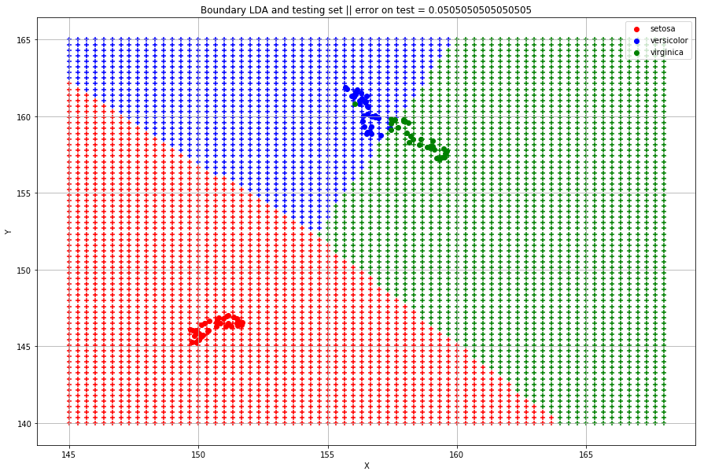

```
time: 385 ms
```

```python
plt.figure(figsize=(15,10))
plt.grid()
plt.xlabel("X")
plt.ylabel("Y")
plt.title("Multiclass classifier")
C=[]
for dot in Testing_set[:,1:]:
    cl=Classifier(np.array(dot),Training_set,1, 'LDA')["Classification Result"]
    C.append(cl)
T=(np.array(C)==Testing_set[:,0])
errLDA=1-(np.count_nonzero(T)/len(Testing_set))
plt.title("Boundary LDA and testing set || error on test = "+str(errLDA))
color=["r","b","g"]
for k in range(3):
    plt.scatter(GRID[GRID[:,0]==k][:,1],GRID[GRID[:,0]==k][:,2],color=color[k],marker='+')
for k in range(3):
    plt.scatter(Testing_set[Testing_set[:,0]==k][:,1],Testing_set[Testing_set[:,0]==k][:,2],color=color[k],label=iris.target_names[k])
plt.legend();
```

**We build a grid and classify each dot of it using QDA classifyer**

```python
GRID=[]
for x in x1:
    for y in x2:
        dot=[x,y]
        cl=Classifier(np.array(dot),Training_set,1, 'QDA')["Classification Result"]
        GRID.append([cl,x,y])
GRID=np.array(GRID)
# Then compute the sampled prediction class_L for each couple (X1,X2)
```

```
time: 1.58 s
```

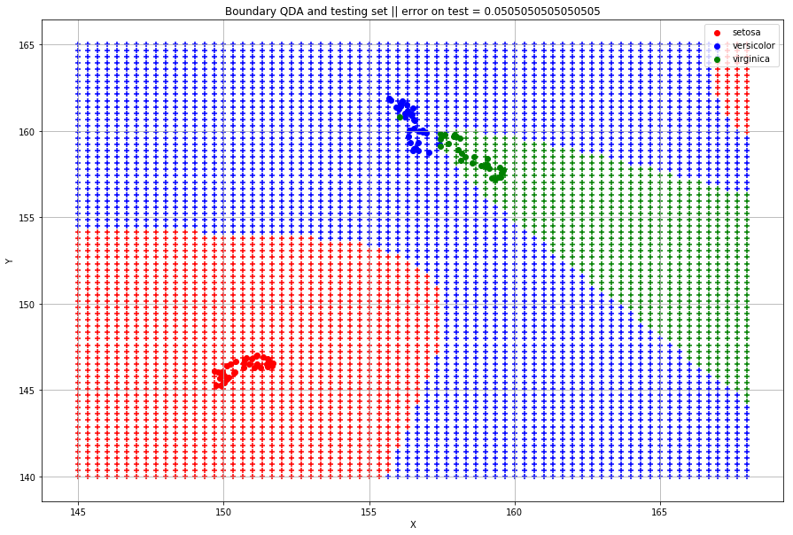

```
time: 360 ms
```

```python
plt.figure(figsize=(15,10))
plt.grid()
plt.xlabel("X")
plt.ylabel("Y")
plt.title("Multiclass classifier")
C=[]
for dot in Testing_set[:,1:]:
    cl=Classifier(np.array(dot),Training_set,1, 'QDA')["Classification Result"]
    C.append(cl)
T=(np.array(C)==Testing_set[:,0])
errQDA=1-(np.count_nonzero(T)/len(Testing_set))
plt.title("Boundary QDA and testing set || error on test = "+str(errQDA))
color=["r","b","g"]
for k in range(3):
    plt.scatter(GRID[GRID[:,0]==k][:,1],GRID[GRID[:,0]==k][:,2],color=color[k],marker='+')
for k in range(3):
    plt.scatter(Testing_set[Testing_set[:,0]==k][:,1],Testing_set[Testing_set[:,0]==k][:,2],color=color[k],label=iris.target_names[k])
plt.legend();
```

```python
cv_scores = []
neighbors=range(1,31)
for k in neighbors:
    knn = KNeighborsClassifier(n_neighbors=k)
    scores = cross_val_score(knn, Training_set[:,1:], Training_set[:,0], cv=10, scoring='accuracy')
    cv_scores.append(scores.mean())
MSE = [1 - x for x in cv_scores]

# determining best k
optimal_k = neighbors[MSE.index(min(MSE))]
neigh = KNeighborsClassifier(n_neighbors=optimal_k)
neigh.fit(Training_set[:,1:], Training_set[:,0])
class_pred=neigh.predict(Testing_set[:,1:])
T=Testing_set[:,0]!=class_pred
errKNN=np.count_nonzero(T)/len(Testing_set)
```

```
time: 280 ms
```

**We build a grid and classify each dot of it using KNN classifyer**

```python
GRID=[]
for x in x1:
    for y in x2:
        dot=[x,y]
        cl=neigh.predict([dot])
        GRID.append([cl,x,y])
GRID=np.array(GRID)
# Then compute the sampled prediction class_L for each couple (X1,X2)
```

```
time: 1.14 s
```

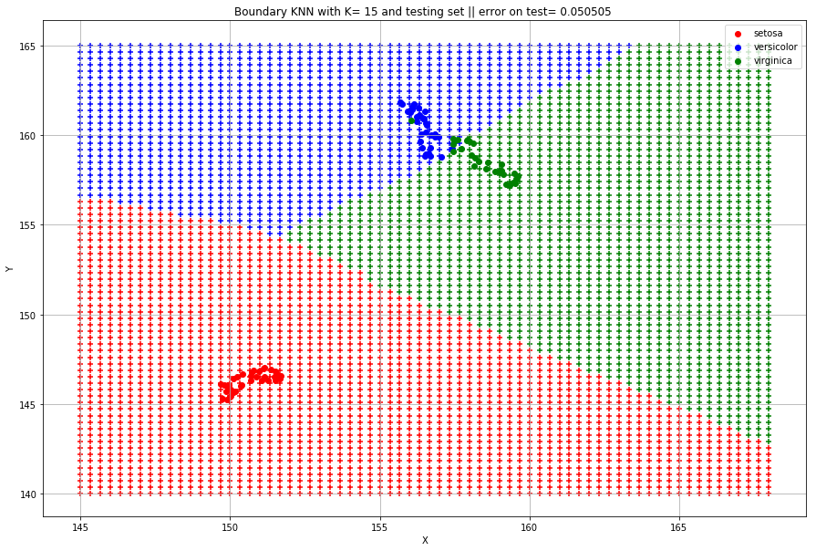

```
time: 311 ms
```

```python
plt.figure(figsize=(15,10))
plt.grid()
plt.xlabel("X")
plt.ylabel("Y")
plt.title("Multiclass classifier")
plt.title("Boundary KNN with K= %d and testing set || error on test= %f " %(optimal_k,errKNN))

color=["r","b","g"]
for k in range(3):
    plt.scatter(GRID[GRID[:,0]==k][:,1],GRID[GRID[:,0]==k][:,2],color=color[k],marker='+')
for k in range(3):
    plt.scatter(Testing_set[Testing_set[:,0]==k][:,1],Testing_set[Testing_set[:,0]==k][:,2],color=color[k],label=iris.target_names[k])
plt.legend();
plt.legend();

errLDAi=errLDA
errQDAi=errQDA
errKNNi=errKNN
optimal_ki=optimal_k
```

# Digits dataset:

```python
from sklearn.datasets import load_digits
```

```
time: 496 µs
```

```python
digits = load_digits()
```

```
time: 130 ms
```

```python
digits.data.shape
```

```
(1797, 64)
```

```
time: 1.49 ms
```

```python
print(digits.DESCR)
```

```
Optical Recognition of Handwritten Digits Data Set
===================================================

Notes
-----
Data Set Characteristics:
    :Number of Instances: 5620
    :Number of Attributes: 64
    :Attribute Information: 8x8 image of integer pixels in the range 0..16.
    :Missing Attribute Values: None
    :Creator: E. Alpaydin (alpaydin '@' boun.edu.tr)
    :Date: July; 1998

This is a copy of the test set of the UCI ML hand-written digits datasets
http://archive.ics.uci.edu/ml/datasets/Optical+Recognition+of+Handwritten+Digits

The data set contains images of hand-written digits: 10 classes where
each class refers to a digit.

Preprocessing programs made available by NIST were used to extract
normalized bitmaps of handwritten digits from a preprinted form. From a
total of 43 people, 30 contributed to the training set and different 13
to the test set. 32x32 bitmaps are divided into nonoverlapping blocks of
4x4 and the number of on pixels are counted in each block. This generates
an input matrix of 8x8 where each element is an integer in the range
0..16. This reduces dimensionality and gives invariance to small
distortions.

For info on NIST preprocessing routines, see M. D. Garris, J. L. Blue, G.
T. Candela, D. L. Dimmick, J. Geist, P. J. Grother, S. A. Janet, and C.
L. Wilson, NIST Form-Based Handprint Recognition System, NISTIR 5469,
1994.

References
----------
  - C. Kaynak (1995) Methods of Combining Multiple Classifiers and Their
    Applications to Handwritten Digit Recognition, MSc Thesis, Institute of
    Graduate Studies in Science and Engineering, Bogazici University.
  - E. Alpaydin, C. Kaynak (1998) Cascading Classifiers, Kybernetika.
  - Ken Tang and Ponnuthurai N. Suganthan and Xi Yao and A. Kai Qin.
    Linear dimensionalityreduction using relevance weighted LDA. School of
    Electrical and Electronic Engineering Nanyang Technological University.
    2005.
  - Claudio Gentile. A New Approximate Maximal Margin Classification
    Algorithm. NIPS. 2000.

time: 991 µs
```

**Same thing as before, we go from 64 dimensions to 2**

```python
embedding = umap.UMAP().fit_transform(digits.data)
```

```
time: 3.37 s
```

```python
embedding
```

```
array([[31.451927, 21.21418 ],
       [19.673027, 21.10674 ],
       [19.02036 , 18.25339 ],
       ...,
       [17.835842, 19.405745],
       [14.140579, 15.446622],
       [17.146767, 19.012272]], dtype=float32)
```

```
time: 28.3 ms
```

```python
targets = [d for d in digits.target_names]

labels = np.array([targets[d] for d in digits.target])

A1=labels[:,None]
A2 = np.concatenate((A1,embedding),axis=1)

Training_set , Testing_set = A2[:601,:] , A2[601:,:]
```

```
time: 2.97 ms
```

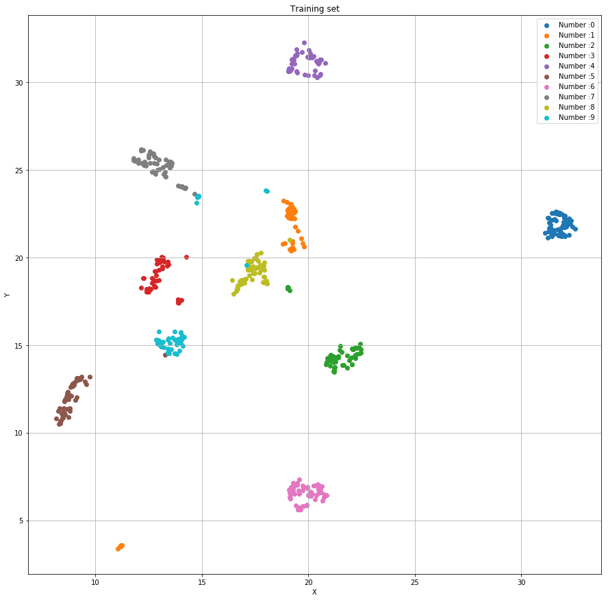

```
time: 226 ms
```

```python
plt.figure(figsize=(15,15))
plt.grid()
plt.title("Training set")
plt.xlabel("X")
plt.ylabel("Y")
for k in np.unique(labels) :
    plt.scatter(Training_set[Training_set[:,0]==k][:,1],Training_set[Training_set[:,0]==k][:,2], label="Number :"+str(k))
plt.legend();
```

```python
Nx1=70 # number of samples for display
Nx2=70
x1=np.linspace(0,40,Nx1)  # sampling of the x1 axis
x2=np.linspace(-10,35,Nx2)  # sampling of the x2 axis
[X1,X2]=np.meshgrid(x1,x2)
```

```
time: 1.46 ms
```

**We build a grid and classify each dot of it using LDA classifyer**

```python
GRID=[]
for x in x1:
    for y in x2:
        dot=[x,y]
        cl=Classifier(np.array(dot),Training_set,1, 'LDA')["Classification Result"]
        GRID.append([cl,x,y])
GRID=np.array(GRID)
```

```
time: 4.66 s
```

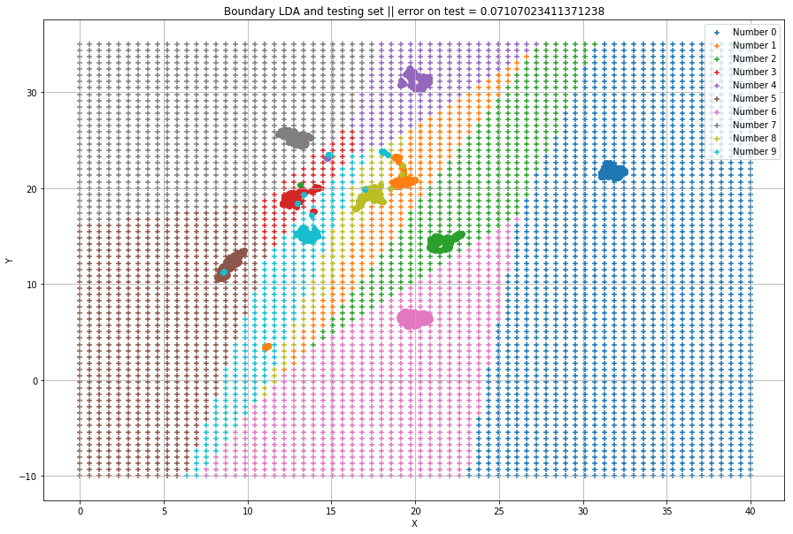

```
time: 2.03 s
```

```python
plt.figure(figsize=(15,10))
plt.grid()
plt.xlabel("X")
plt.ylabel("Y")
plt.title("Multiclass classifier")
C=[]
for dot in Testing_set[:,1:]:
    cl=Classifier(np.array(dot),Training_set,1, 'LDA')["Classification Result"]
    C.append(cl)
T=(np.array(C)==Testing_set[:,0])
errLDA=1-(np.count_nonzero(T)/len(Testing_set))
plt.title("Boundary LDA and testing set || error on test = "+str(errLDA))

for k in range(10):
    plt.scatter(GRID[GRID[:,0]==k][:,1],GRID[GRID[:,0]==k][:,2],label='Number %d'%k,marker='+')
for k in range(10):
    plt.scatter(Testing_set[Testing_set[:,0]==k][:,1],Testing_set[Testing_set[:,0]==k][:,2])

plt.legend();
```

**We build a grid and classify each dot of it using QDA classifyer**

```python
GRID=[]
for x in x1:
    for y in x2:
        dot=[x,y]
        cl=Classifier(np.array(dot),Training_set,1, 'QDA')["Classification Result"]
        GRID.append([cl,x,y])
GRID=np.array(GRID)
```

```
time: 6.21 s
```

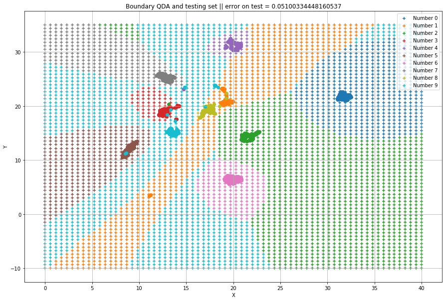

```
time: 2.06 s
```

```python
plt.figure(figsize=(15,10))
plt.grid()
plt.xlabel("X")
plt.ylabel("Y")
plt.title("Multiclass classifier")
C=[]
for dot in Testing_set[:,1:]:
    cl=Classifier(np.array(dot),Training_set,1, 'QDA')["Classification Result"]
    C.append(cl)
T=1*(np.array(C)==Testing_set[:,0])
errQDA=1-(np.count_nonzero(T)/len(Testing_set))
plt.title("Boundary QDA and testing set || error on test = "+str(errQDA))

for k in range(10):
    plt.scatter(GRID[GRID[:,0]==k][:,1],GRID[GRID[:,0]==k][:,2],label='Number %d'%k,marker='+')
for k in range(10):
    plt.scatter(Testing_set[Testing_set[:,0]==k][:,1],Testing_set[Testing_set[:,0]==k][:,2])

plt.legend();
```

```python
cv_scores = []
neighbors=range(1,31)
for k in neighbors:
    knn = KNeighborsClassifier(n_neighbors=k)
    scores = cross_val_score(knn, Training_set[:,1:], Training_set[:,0], cv=10, scoring='accuracy')
    cv_scores.append(scores.mean())
MSE = [1 - x for x in cv_scores]

# determining best k
optimal_k = neighbors[MSE.index(min(MSE))]
neigh = KNeighborsClassifier(n_neighbors=optimal_k)
neigh.fit(Training_set[:,1:], Training_set[:,0])
class_pred=neigh.predict(Testing_set[:,1:])
T=Testing_set[:,0]!=class_pred
errKNN=np.count_nonzero(T)/len(Testing_set)
```

```
time: 488 ms
```

**We build a grid and classify each dot of it using KNN classifyer**

```python
GRID=[]
for x in x1:
    for y in x2:
        dot=[x,y]
        cl=neigh.predict([dot])
        GRID.append([cl,x,y])
GRID=np.array(GRID)
```

```
time: 1.24 s
```

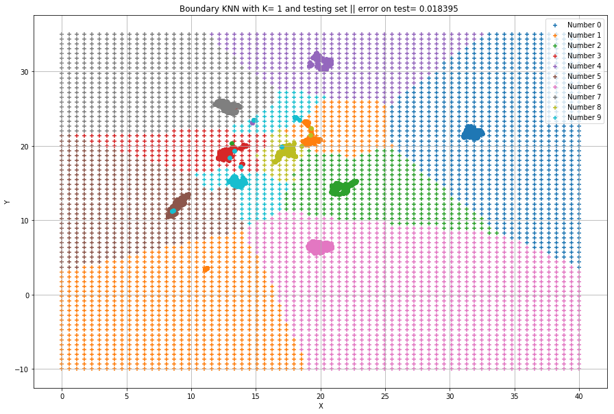

```
time: 561 ms
```

```python
plt.figure(figsize=(15,10))
plt.grid()
plt.xlabel("X")
plt.ylabel("Y")
plt.title("Multiclass classifier")
plt.title("Boundary KNN with K= %d and testing set || error on test= %f " %(optimal_k,errKNN))

for k in range(10):
    plt.scatter(GRID[GRID[:,0]==k][:,1],GRID[GRID[:,0]==k][:,2],label='Number %d'%k,marker='+')
for k in range(10):
    plt.scatter(Testing_set[Testing_set[:,0]==k][:,1],Testing_set[Testing_set[:,0]==k][:,2])
#     plt.scatter(Training_set[Training_set[:,0]==k][:,1],Training_set[Training_set[:,0]==k][:,2])
plt.legend();
```

**Conclusion**

**Iris**

```python
print("The generalisation error of LDA binary classifier = %f" % errLDAi)
print('--'*50)
print("The generalisation error of QDA binary classifier = %f" % errQDAi)
print('--'*50)
print("The generalisation error of %d-NN binary classifier = %f" %(optimal_ki ,errKNNi))
print('--'*50)
```

```
The generalisation error of LDA binary classifier = 0.050505
----------------------------------------------------------------------------------------------------
The generalisation error of QDA binary classifier = 0.050505
----------------------------------------------------------------------------------------------------
The generalisation error of 15-NN binary classifier = 0.050505
----------------------------------------------------------------------------------------------------
time: 1.49 ms
```

**digits**

```python
print("The generalisation error of LDA binary classifier = %f" % errLDA)
print('--'*50)
print("The generalisation error of QDA binary classifier = %f" % errQDA)
print('--'*50)
print("The generalisation error of %d-NN binary classifier = %f" %(optimal_k ,errtest))
print('--'*50)
```

[output not shown]

One test is just not enought to draw conclusions

**Just like before, we will bootstrap data from training sets $100$ times and visualise the errors**

**But this time let us use the scikit learn LDA and QDA methods** *(to speed things up)*

## TO DO : LDA & QDA using scikit-learn module

The module `scikit-learn` is dedicated to machine learning algorithms. Many of them are available in a simple manner. For LDA and QDA, have a look at the tutorial available at http://scikit-learn.org/stable/modules/lda_qda.html

**Warning** : you may have a critical view of the way LDA and QDA are illustrated in the proposed example...

```python
from sklearn.discriminant_analysis import LinearDiscriminantAnalysis
from sklearn.discriminant_analysis import QuadraticDiscriminantAnalysis
```

```
time: 160 ms
```

**The covariances matrices in these methods are just estimated (not hard computed) which mean that we get probabilities that do not exactly sum up to 1**

**Iris**

```python
errQDA=[]
errLDA=[]
errKNN=[]
N_experiences=100
embedding2 = umap.UMAP(n_neighbors=50,
                      learning_rate=0.5,
                      init="random",
                      min_dist=0.001)\
                .fit_transform(iris.data)
targets = np.array([d for d in iris.target])
# labels2 = np.array([targets2[d] for d in iris.target])
A12=targets[:,None]
A22 = np.concatenate((A12,embedding2),axis=1)
Training_set,Testing_set=A22[51:],A22[51:]
for i in range(N_experiences):

    bs=resample_with_replacement(Training_set)
    errLDA.append(1-np.count_nonzero((LinearDiscriminantAnalysis().fit(bs[:,1:],bs[:,0])
                                      .predict(Testing_set[:,1:])==Testing_set[:,0]))/len(Testing_set))
    errQDA.append(1-np.count_nonzero((QuadraticDiscriminantAnalysis().fit(bs[:,1:],bs[:,0])
                                      .predict(Testing_set[:,1:])==Testing_set[:,0]))/len(Testing_set))
    cv_scores = []
    neighbors=range(1,31)
    for k in neighbors:
        knn = KNeighborsClassifier(n_neighbors=k)
        scores = cross_val_score(knn, bs[:,1:], bs[:,0], cv=10, scoring='accuracy')
        cv_scores.append(scores.mean())
    MSE = [1 - x for x in cv_scores]

    # determining best k
    optimal_k = neighbors[MSE.index(min(MSE))]
    neigh = KNeighborsClassifier(n_neighbors=optimal_k)
    neigh.fit(bs[:,1:], bs[:,0])
    class_pred=neigh.predict(Testing_set[:,1:])
    T=Testing_set[:,0]!=class_pred
    errKNN.append(np.count_nonzero(T)/len(Testing_set))
```

```
time: 32.7 s
```

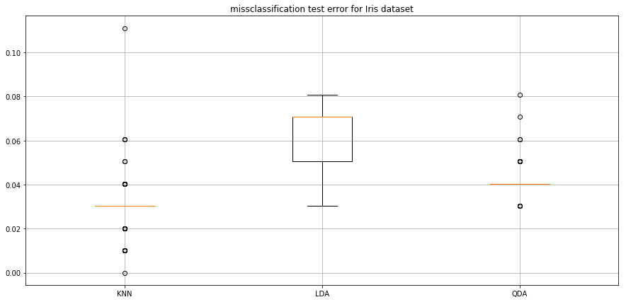

```
time: 148 ms
```

```python
plt.figure(figsize=(15,7))
plt.title("missclassification test error for Iris dataset")
plt.grid()
plt.boxplot([errKNN,errLDA,errQDA],labels=["KNN","LDA",'QDA']);
```

**digits**

```python
errQDA=[]
errLDA=[]
errKNN=[]
N_experiences=100
embedding2 = umap.UMAP(n_neighbors=50,
                      learning_rate=0.5,
                      init="random",
                      min_dist=0.001)\
                .fit_transform(digits.data)
targets = np.array([d for d in digits.target])
A12=targets[:,None]
A22 = np.concatenate((A12,embedding2),axis=1)
Training_set,Testing_set=A22[601:],A22[601:]
for i in range(N_experiences):

    bs=resample_with_replacement(Training_set)
    errLDA.append(1-np.count_nonzero((LinearDiscriminantAnalysis().fit(bs[:,1:],bs[:,0])
                                      .predict(Testing_set[:,1:])==Testing_set[:,0]))/len(Testing_set))
    errQDA.append(1-np.count_nonzero((QuadraticDiscriminantAnalysis().fit(bs[:,1:],bs[:,0])
                                      .predict(Testing_set[:,1:])==Testing_set[:,0]))/len(Testing_set))
    cv_scores = []
    neighbors=range(1,31)
    for k in neighbors:
        knn = KNeighborsClassifier(n_neighbors=k)
        scores = cross_val_score(knn, bs[:,1:], bs[:,0], cv=10, scoring='accuracy')
        cv_scores.append(scores.mean())
    MSE = [1 - x for x in cv_scores]

    # determining best k
    optimal_k = neighbors[MSE.index(min(MSE))]
    neigh = KNeighborsClassifier(n_neighbors=optimal_k)
    neigh.fit(bs[:,1:], bs[:,0])
    class_pred=neigh.predict(Testing_set[:,1:])
    T=Testing_set[:,0]!=class_pred
    errKNN.append(np.count_nonzero(T)/len(Testing_set))
```

[output not shown]

```
time: 1min 9s
```

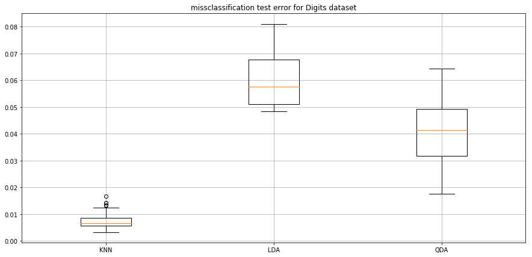

```
time: 135 ms
```

```python
plt.figure(figsize=(15,7))
plt.title("missclassification test error for Digits dataset")
plt.grid()
plt.boxplot([errKNN,errLDA,errQDA],labels=["KNN","LDA",'QDA']);
```

**Conclusion**

What we conclude from all this is:

- if we have a 2D dimensional problem: Binary ==> use QDA || multiclass ==> use KNN with K determined by cross validation

But KNN is not always the adequate solution as it fails to perform well in high dimentional problems as told in the course. ( We may not always want to use dimensional reduction because by doing so we lose interpretation of data and we become kind of "blindtrusting" what the algorithm returns)

**To confirm this, lets apply LDA, QDA and KNN for the iris data directly without dimension reduction ( directly on 4-D space) with bootstraping training data.**

```python
errQDA=[]
errLDA=[]
errKNN=[]
N_experiences=100
targets = np.array([d for d in iris.target])
# labels2 = np.array([targets2[d] for d in iris.target])
A12=targets[:,None]
A22 = np.concatenate((A12,iris.data),axis=1)
np.random.shuffle(A22)
Training_set,Testing_set=A22[51:],A22[51:]
for i in range(N_experiences):

    bs=resample_with_replacement(Training_set)
    errLDA.append(1-np.count_nonzero((LinearDiscriminantAnalysis().fit(bs[:,1:],bs[:,0])
                                      .predict(Testing_set[:,1:])==Testing_set[:,0]))/len(Testing_set))
    errQDA.append(1-np.count_nonzero((QuadraticDiscriminantAnalysis().fit(bs[:,1:],bs[:,0])
                                      .predict(Testing_set[:,1:])==Testing_set[:,0]))/len(Testing_set))
    cv_scores = []
    neighbors=range(1,31)
    for k in neighbors:
        knn = KNeighborsClassifier(n_neighbors=k)
        scores = cross_val_score(knn, bs[:,1:], bs[:,0], cv=10, scoring='accuracy')
        cv_scores.append(scores.mean())
    MSE = [1 - x for x in cv_scores]

    # determining best k
    optimal_k = neighbors[MSE.index(min(MSE))]
    neigh = KNeighborsClassifier(n_neighbors=optimal_k)
    neigh.fit(bs[:,1:], bs[:,0])
    class_pred=neigh.predict(Testing_set[:,1:])
    T=Testing_set[:,0]!=class_pred
    errKNN.append(np.count_nonzero(T)/len(Testing_set))
```

```
time: 29.6 s
```

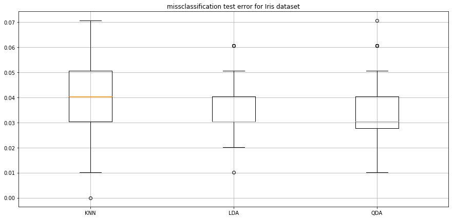

```
time: 127 ms
```

```python
plt.figure(figsize=(15,7))
plt.title("missclassification test error for Iris dataset")
plt.grid()
plt.boxplot([errKNN,errLDA,errQDA],labels=["KNN","LDA",'QDA']);
```

Our assemption confirms itself a bit, but the KNN error is not that far away from LDA and QDA errors after all. ( because we do not have that many dimensions).

```python
import warnings
warnings.filterwarnings('ignore')
```

```
time: 496 µs
```

```python
errQDA=[]
errLDA=[]
errKNN=[]
N_experiences=50
targets = np.array([d for d in digits.target])
# labels2 = np.array([targets2[d] for d in iris.target])
A12=targets[:,None]
A22 = np.concatenate((A12,digits.data),axis=1)
Training_set,Testing_set=A22[601:],A22[601:]
for i in range(N_experiences):

    bs=resample_with_replacement(Training_set)
    errLDA.append(1-np.count_nonzero((LinearDiscriminantAnalysis().fit(bs[:,1:],bs[:,0])
                                      .predict(Testing_set[:,1:])==Testing_set[:,0]))/len(Testing_set))
    errQDA.append(1-np.count_nonzero((QuadraticDiscriminantAnalysis().fit(bs[:,1:],bs[:,0])
                                      .predict(Testing_set[:,1:])==Testing_set[:,0]))/len(Testing_set))
    cv_scores = []
    neighbors=range(1,31)
    for k in neighbors:
        knn = KNeighborsClassifier(n_neighbors=k)
        scores = cross_val_score(knn, bs[:,1:], bs[:,0], cv=10, scoring='accuracy')
        cv_scores.append(scores.mean())
    MSE = [1 - x for x in cv_scores]

    # determining best k
    optimal_k = neighbors[MSE.index(min(MSE))]
    neigh = KNeighborsClassifier(n_neighbors=optimal_k)
    neigh.fit(bs[:,1:], bs[:,0])
    class_pred=neigh.predict(Testing_set[:,1:])
    T=Testing_set[:,0]!=class_pred
    errKNN.append(np.count_nonzero(T)/len(Testing_set))
```

```
time: 3min 55s
```

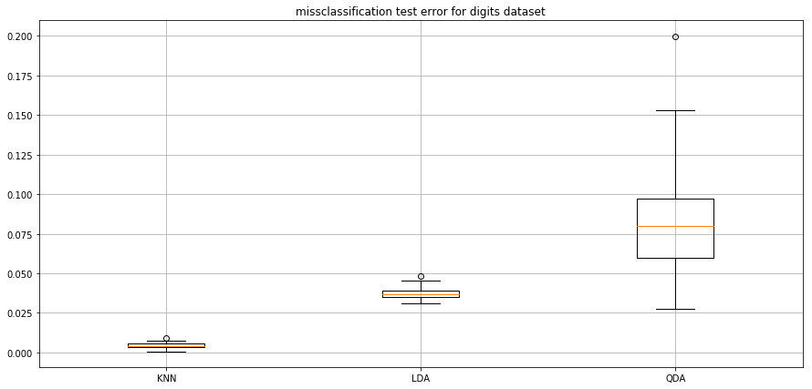

```
time: 127 ms
```

```python
plt.figure(figsize=(15,7))
plt.title("missclassification test error for digits dataset")
plt.grid()
plt.boxplot([errKNN,errLDA,errQDA],labels=["KNN","LDA",'QDA']);
```

At first we though that this digits dataset is high dimensional, but after discussing with M.Bardenet, we realised it is not really what we thought ( the sides and corners of the pictures are nearly always blank and there is some regularity in the values that these dimensions can take)

This may explain why KNN is still performing well.

**Using another Dataset high dimensional dataset : Urban Land Cover**

- It contains training and testing data for classifying a high resolution aerial image into 9 types of urban land cover. Multi-scale spectral, size, shape, and texture information are used for classification. There are a low number of training samples for each class (14-30) and a high number of classification variables (148). The testing data set is from a random sampling of the image. Class is the target classification variable. The land cover classes are: trees, grass, soil, concrete, asphalt, buildings, cars, pools, shadows

```python
Urban_land_cover_train = pd.read_csv('Urban_land_cover_training.csv', header = 0, delimiter=",")
Urban_land_cover_test= pd.read_csv('Urban_land_cover_testing.csv', header = 0, delimiter=",")
```

```
time: 1.97 s
```

```python
Urban_land_cover_DataSet= Urban_land_cover_train.append(Urban_land_cover_test,ignore_index=True)
```

```
time: 112 ms
```

```python
Urban_land_cover_DataSet.head()
```

|  | class | BrdIndx | Area | Round | Bright | Compact | ShpIndx | Mean_G | Mean_R | Mean_NIR | ... | SD_NIR_140 | LW_140 | GLCM1_140 | Rect_140 | GLCM2_140 | Dens_140 | Assym_140 | NDVI_140 | BordLngth_140 | GLCM3_140 |
| --- | --- | --- | --- | --- | --- | --- | --- | --- | --- | --- | --- | --- | --- | --- | --- | --- | --- | --- | --- | --- | --- |
| 0 | car | 1.27 | 91 | 0.97 | 231.38 | 1.39 | 1.47 | 207.92 | 241.74 | 244.48 | ... | 26.18 | 2.00 | 0.50 | 0.85 | 6.29 | 1.67 | 0.70 | -0.08 | 56 | 3806.36 |
| 1 | concrete | 2.36 | 241 | 1.56 | 216.15 | 2.46 | 2.51 | 187.85 | 229.39 | 231.20 | ... | 22.29 | 2.25 | 0.79 | 0.55 | 8.42 | 1.38 | 0.81 | -0.09 | 1746 | 1450.14 |
| 2 | concrete | 2.12 | 266 | 1.47 | 232.18 | 2.07 | 2.21 | 206.54 | 244.22 | 245.79 | ... | 15.59 | 2.19 | 0.76 | 0.74 | 7.24 | 1.68 | 0.81 | -0.07 | 566 | 1094.04 |
| 3 | concrete | 2.42 | 399 | 1.28 | 230.40 | 2.49 | 2.73 | 204.60 | 243.27 | 243.32 | ... | 13.51 | 3.34 | 0.82 | 0.74 | 7.44 | 1.36 | 0.92 | -0.09 | 1178 | 1125.38 |
| 4 | concrete | 2.15 | 944 | 1.73 | 193.18 | 2.28 | 4.10 | 165.98 | 205.55 | 208.00 | ... | 15.65 | 50.08 | 0.85 | 0.49 | 8.15 | 0.23 | 1.00 | -0.08 | 6232 | 1146.38 |

5 rows × 148 columns

```
time: 110 ms
```

```python
# converting the column class to a numeric catagoric class
Urban_land_cover_DataSet['class']= Urban_land_cover_DataSet['class'].astype("category").cat.codes
```

```
time: 103 ms
```

```python
Urban_land_cover_DataSet.head()
```

|  | class | BrdIndx | Area | Round | Bright | Compact | ShpIndx | Mean_G | Mean_R | Mean_NIR | ... | SD_NIR_140 | LW_140 | GLCM1_140 | Rect_140 | GLCM2_140 | Dens_140 | Assym_140 | NDVI_140 | BordLngth_140 | GLCM3_140 |
| --- | --- | --- | --- | --- | --- | --- | --- | --- | --- | --- | --- | --- | --- | --- | --- | --- | --- | --- | --- | --- | --- |
| 0 | 2 | 1.27 | 91 | 0.97 | 231.38 | 1.39 | 1.47 | 207.92 | 241.74 | 244.48 | ... | 26.18 | 2.00 | 0.50 | 0.85 | 6.29 | 1.67 | 0.70 | -0.08 | 56 | 3806.36 |
| 1 | 3 | 2.36 | 241 | 1.56 | 216.15 | 2.46 | 2.51 | 187.85 | 229.39 | 231.20 | ... | 22.29 | 2.25 | 0.79 | 0.55 | 8.42 | 1.38 | 0.81 | -0.09 | 1746 | 1450.14 |
| 2 | 3 | 2.12 | 266 | 1.47 | 232.18 | 2.07 | 2.21 | 206.54 | 244.22 | 245.79 | ... | 15.59 | 2.19 | 0.76 | 0.74 | 7.24 | 1.68 | 0.81 | -0.07 | 566 | 1094.04 |
| 3 | 3 | 2.42 | 399 | 1.28 | 230.40 | 2.49 | 2.73 | 204.60 | 243.27 | 243.32 | ... | 13.51 | 3.34 | 0.82 | 0.74 | 7.44 | 1.36 | 0.92 | -0.09 | 1178 | 1125.38 |
| 4 | 3 | 2.15 | 944 | 1.73 | 193.18 | 2.28 | 4.10 | 165.98 | 205.55 | 208.00 | ... | 15.65 | 50.08 | 0.85 | 0.49 | 8.15 | 0.23 | 1.00 | -0.08 | 6232 | 1146.38 |

5 rows × 148 columns

```
time: 16.4 ms
```

```python
DataSet = Urban_land_cover_DataSet.values
```

```
time: 101 ms
```

```python
errQDA=[]
errLDA=[]
errKNN=[]
N_experiences=100
Training_set,Testing_set=DataSet[168:],DataSet[169:]
for i in range(N_experiences):

    bs=resample_with_replacement(Training_set)
    errLDA.append(1-np.count_nonzero((LinearDiscriminantAnalysis().fit(bs[:,1:],bs[:,0])
                                      .predict(Testing_set[:,1:])==Testing_set[:,0]))/len(Testing_set))
    errQDA.append(1-np.count_nonzero((QuadraticDiscriminantAnalysis().fit(bs[:,1:],bs[:,0])
                                      .predict(Testing_set[:,1:])==Testing_set[:,0]))/len(Testing_set))
    cv_scores = []
    neighbors=range(1,31)
    for k in neighbors:
        knn = KNeighborsClassifier(n_neighbors=k)
        scores = cross_val_score(knn, bs[:,1:], bs[:,0], cv=10, scoring='accuracy')
        cv_scores.append(scores.mean())
    MSE = [1 - x for x in cv_scores]

    # determining best k
    optimal_k = neighbors[MSE.index(min(MSE))]
    neigh = KNeighborsClassifier(n_neighbors=optimal_k)
    neigh.fit(bs[:,1:], bs[:,0])
    class_pred=neigh.predict(Testing_set[:,1:])
    T=Testing_set[:,0]!=class_pred
    errKNN.append(np.count_nonzero(T)/len(Testing_set))
```

```
time: 2min 30s
```

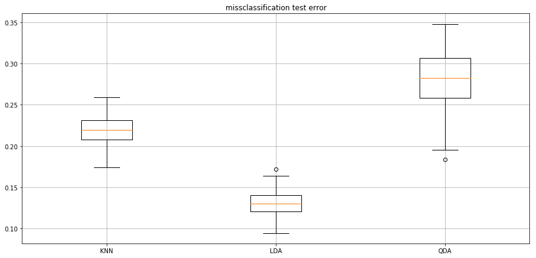

```
time: 139 ms
```

```python
plt.figure(figsize=(15,7))
plt.title("missclassification test error")
plt.grid()
plt.boxplot([errKNN,errLDA,errQDA],labels=["KNN","LDA",'QDA']);
```

**Now we can safely commet about our previous statement and build more robust conclusions**